# Data processing for assignment 2

Cas Blaauw, Dominic Comerford and Netanja Harlianto

09/06/2020

### Introduction

We chose the Coffee Quality dataset, which has been scraped from the Coffee Quality Institute database in 2018. Our dataset contains information on two different coffee plants: Arabica and Robusta. Information about quality measures, coffee bean data, and farm data are included. Quality measures include: aroma, flavor, aftertaste, acidity, body, balance, uniformity, cup cleanliness, sweetness, moisture, and defects. Bean data includes the species, color, and the method of processing. Farm data in which we are interested includes region/country of origin, and the altitude at which the farm is located with respect to sea level.

### Preparatory work

```r
library(tidyverse)
library(dplyr)
library(mice)
coffee <- read_csv("coffee.sort.csv") %>%
  mutate(across(where(is.character), as.factor)) #Needs updated dplyr
```

### Missing data per column

```r
colSums(is.na(coffee))
```

```
##              Species    Country.of.Origin               Region
##                    0                    1                   59
##            Farm.Name                Owner              Company
##                  359                    7                  209
##   Certification.Body  unit_of_measurement             Altitude
##                    0                    0                  226
## altitude_high_meters  altitude_low_meters altitude_mean_meters
##                  230                  230                  230
##       Number.of.Bags           Bag.Weight         Harvest.Year
##                    0                    0                   47
##         Grading.Date           Expiration              Variety
##                    0                    0                  226
##    Processing.Method                Aroma               Flavor
##                  170                    0                    0
##           Aftertaste              Acidity                 Body
##                    0                    0                    0
##              Balance           Uniformity            Clean.Cup
##                    0                    0                    0
##            Sweetness        Cupper.Points     Total.Cup.Points
##                    0                    0                    0
##             Moisture Category.One.Defects Category.Two.Defects
##                    0                    0                    0
##              Quakers                Color
##                    1                  218
```

#### Missing data in the country of origin

There is one NA value in the country of origin. This coffee does have an owner and certification body that both only operate in Colombia according to their websites. Also, all coffees in the data with those owners and that certification body are Colombian. Therefore, we assign this missing value to be Colombia.

```r
coffee %>% filter(is.na(Country.of.Origin))
```

```
## # A tibble: 1 x 35
##   Species Country.of.Origin Region Farm.Name Owner              Company Certification.B~
##   <fct>   <fct>             <fct>  <fct>     <fct>              <fct>   <fct>
## 1 Arabica <NA>              <NA>   <NA>      racafe & cia s.c.a <NA>    Almacafé
## # ... with 28 more variables: unit_of_measurement <fct>, Altitude <fct>,
## #   altitude_high_meters <dbl>, altitude_low_meters <dbl>,
## #   altitude_mean_meters <dbl>, Number.of.Bags <dbl>, Bag.Weight <fct>,
## #   Harvest.Year <fct>, Grading.Date <fct>, Expiration <fct>, Variety <fct>,
## #   Processing.Method <fct>, Aroma <dbl>, Flavor <dbl>, Aftertaste <dbl>,
## #   Acidity <dbl>, Body <dbl>, Balance <dbl>, Uniformity <dbl>,
## #   Clean.Cup <dbl>, Sweetness <dbl>, Cupper.Points <dbl>, ...
```

```r
coffee %>%
  filter(Owner == "racafe & cia s.c.a" & Certification.Body == "Almacafé") %>%
  count(Country.of.Origin)
```

```
## # A tibble: 2 x 2
##   Country.of.Origin     n
##   <fct>             <int>
## 1 Colombia             59
## 2 <NA>                  1
```

```r
coffee <- coffee %>%
  mutate(Country.of.Origin = replace(Country.of.Origin,
                                     Owner == "racafe & cia s.c.a" &
                                       Certification.Body == "Almacafé" &
                                       is.na(Country.of.Origin),
                                     "Colombia"))
```

#### Delete erroneous data points

In the ranking categories, all values lie between at least 5 and 10, except for one coffee, which has 0 in all values. To delete this erroneous value, we keep all coffees that have at least one taste metric above 5.

In the altitude category, we spot a clear outlier, which could affect the imputation process. Given that an altitude of over 10000m seems highly unlikely, we filter these out as well.

```r
# Look at data distributions
coffee %>%
  summary()
```

```
##     Species                  Country.of.Origin            Region
##  Arabica:1311   Mexico                :236     huila         :112
##  Robusta:  28   Colombia              :184     oriente       : 80
##                 Guatemala             :181     south of minas: 68
##                 Brazil                :132     kona          : 66
##                 Taiwan                : 75     veracruz      : 35
##                 United States (Hawaii): 73     (Other)       :919
##                 (Other)               :458     NA's          : 59
##                         Farm.Name                                Owner
##  various                     : 47   juan luis alvarado romero       :155
##  rio verde                   : 23   racafe & cia s.c.a              : 60
##  several                     : 20   exportadora de cafe condor s.a  : 54
##  finca medina                : 15   kona pacific farmers cooperative: 52
##  doi tung development project: 13   ipanema coffees                 : 50
##  (Other)                     :862   (Other)                         :961
##  NA's                        :359   NA's                            :  7
##                              Company
##  unex guatemala, s.a.            : 86
##  ipanema coffees                 : 50
##  exportadora de cafe condor s.a  : 40
##  kona pacific farmers cooperative: 40
##  racafe & cia s.c.a              : 40
##  (Other)                         :874
##  NA's                            :209
##                            Certification.Body unit_of_measurement    Altitude
##  Specialty Coffee Association       :313      ft: 182             1100   : 43
##  AMECAFE                            :205      m :1157             1200   : 42
##  Almacafé                           :178                          1300   : 32
##  Asociacion Nacional Del Café       :155                          1400   : 32
##  Brazil Specialty Coffee Association: 67                          4300   : 31
##  Instituto Hondureño del Café       : 60                          (Other):933
##  (Other)                            :361                          NA's   :226
##  altitude_high_meters altitude_low_meters altitude_mean_meters Number.of.Bags
##  Min.   :     1       Min.   :     1      Min.   :     1       Min.   :   0.0
##  1st Qu.:  1100       1st Qu.:  1100      1st Qu.:  1100       1st Qu.:  14.0
##  Median :  1350       Median :  1311      Median :  1311       Median : 175.0
##  Mean   :  1799       Mean   :  1751      Mean   :  1775       Mean   : 154.2
##  3rd Qu.:  1650       3rd Qu.:  1600      3rd Qu.:  1600       3rd Qu.: 275.0
##  Max.   :190164       Max.   :190164      Max.   :190164       Max.   :1062.0
##  NA's   :230          NA's   :230         NA's   :230
```

[output cut: 33 more lines]

```
##  Min.   : 0.000   Min.   : 0.00    Min.   :0.00000   Min.   : 0.0000
##  1st Qu.: 7.250   1st Qu.:81.08    1st Qu.:0.09000   1st Qu.: 0.0000
##  Median : 7.500   Median :82.50    Median :0.11000   Median : 0.0000
##  Mean   : 7.503   Mean   :82.09    Mean   :0.08838   Mean   : 0.4795
##  3rd Qu.: 7.750   3rd Qu.:83.67    3rd Qu.:0.12000   3rd Qu.: 0.0000
##  Max.   :10.000   Max.   :90.58    Max.   :0.28000   Max.   :63.0000
##
##  Category.Two.Defects    Quakers                 Color
##  Min.   : 0.000       Min.   : 0.0000   Blue-Green  : 85
##  1st Qu.: 0.000       1st Qu.: 0.0000   Bluish-Green:114
##  Median : 2.000       Median : 0.0000   Green       :870
##  Mean   : 3.556       Mean   : 0.1734   None        : 52
##  3rd Qu.: 4.000       3rd Qu.: 0.0000   NA's        :218
##  Max.   :55.000       Max.   :11.0000
##                       NA's   :1
```

```r
# Filter out unexpected rankings
coffee %>%
  filter(Aroma < 5 | Flavor < 5 | Aftertaste < 5 | Acidity < 5 | Body < 5 | Balance < 5 | Uniformity < 5)
```

```
## # A tibble: 1 x 35
##   Species Country.of.Origin Region    Farm.Name    Owner           Company Certification.B~
##   <fct>   <fct>             <fct>     <fct>        <fct>           <fct>   <fct>
## 1 Arabica Honduras          comayagua los hicaques bismarck castro cigrah~ Instituto Hondu~
## # ... with 28 more variables: unit_of_measurement <fct>, Altitude <fct>,
## #   altitude_high_meters <dbl>, altitude_low_meters <dbl>,
## #   altitude_mean_meters <dbl>, Number.of.Bags <dbl>, Bag.Weight <fct>,
## #   Harvest.Year <fct>, Grading.Date <fct>, Expiration <fct>, Variety <fct>,
## #   Processing.Method <fct>, Aroma <dbl>, Flavor <dbl>, Aftertaste <dbl>,
## #   Acidity <dbl>, Body <dbl>, Balance <dbl>, Uniformity <dbl>,
## #   Clean.Cup <dbl>, Sweetness <dbl>, Cupper.Points <dbl>, ...
```

```r
coffee <-
  coffee %>%
  filter(Aroma > 5 | Flavor > 5 | Aftertaste > 5 | Acidity > 5 | Body > 5 | Balance > 5 | Uniformity > 5)

coffee %>%
  select(Aroma:Uniformity) %>%
  summary()
```

```
##      Aroma           Flavor        Aftertaste       Acidity
##  Min.   :5.080   Min.   :6.080   Min.   :6.170   Min.   :5.250
##  1st Qu.:7.420   1st Qu.:7.330   1st Qu.:7.250   1st Qu.:7.330
##  Median :7.580   Median :7.580   Median :7.420   Median :7.580
##  Mean   :7.572   Mean   :7.526   Mean   :7.407   Mean   :7.541
##  3rd Qu.:7.750   3rd Qu.:7.750   3rd Qu.:7.580   3rd Qu.:7.750
##  Max.   :8.750   Max.   :8.830   Max.   :8.670   Max.   :8.750
##       Body          Balance        Uniformity
##  Min.   :5.080   Min.   :5.250   Min.   : 6.000
##  1st Qu.:7.330   1st Qu.:7.330   1st Qu.:10.000
##  Median :7.500   Median :7.500   Median :10.000
##  Mean   :7.523   Mean   :7.524   Mean   : 9.842
##  3rd Qu.:7.670   3rd Qu.:7.750   3rd Qu.:10.000
##  Max.   :8.580   Max.   :8.750   Max.   :10.000
```

```r
# Filter out unexpected mean altitude
summary(coffee$altitude_mean_meters)
```

```
##    Min. 1st Qu.  Median    Mean 3rd Qu.    Max.    NA's
##       1    1100    1311    1775    1600  190164     230
```

```r
coffee <- filter(coffee,
                 altitude_mean_meters < 10000.000 | is.na(altitude_mean_meters)) #Keep proper values and NAs
```

#### Imputation of larger amounts of missing data

The selected columns with missing data includes quakers, altitude_mean_meters, color, and processing method. The number of complete cases in our selected coffee dataset is 930 (down from 1334). Complete case analysis decreases our sample size, and can potentially lead to reduced statistical efficiency by increasing the potential for bias. Another option is multiple imputation, as our sample size will be preserved.

We choose to handle our missing data problem by using multiple imputation.

```r
coffee_select <- coffee %>% select(Species, Country.of.Origin, altitude_mean_meters, Processing.Method:Color) # These variables seem most interesting and applicable for imputation
colnames(coffee_select)
```

```
##  [1] "Species"              "Country.of.Origin"    "altitude_mean_meters"
##  [4] "Processing.Method"    "Aroma"                "Flavor"
##  [7] "Aftertaste"           "Acidity"              "Body"
## [10] "Balance"              "Uniformity"           "Clean.Cup"
## [13] "Sweetness"            "Cupper.Points"        "Total.Cup.Points"
## [16] "Moisture"             "Category.One.Defects" "Category.Two.Defects"
## [19] "Quakers"              "Color"
```

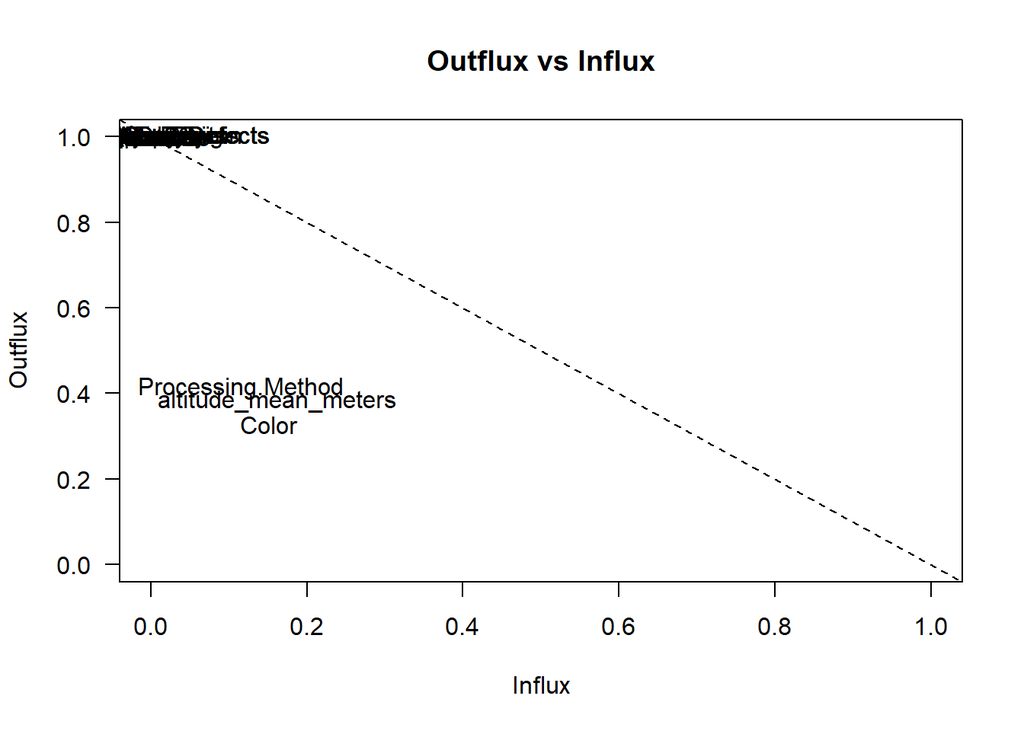

```r
fluxplot(coffee_select, labels = TRUE, main = "Outflux vs Influx", eqscplot = FALSE) # This plot indicates which variables to use
```

```r
set.seed(1000)
ini <- mice(coffee_select, maxit = 0, print = FALSE)
pred <- ini$pred

pred[ "altitude_mean_meters", c("Processing.Method", "Color")] <- 0
pred[ "Processing.Method", c("altitude_mean_meters", "Color") ] <- 0
pred[ "Quakers", c("altitude_mean_meters", "Processing.Method", "Color")  ] <- 0
pred[ "Color" , c("altitude_mean_meters", "Processing.Method") ] <- 0

meth <- ini$method  # Predictive mean matching for continous variables and a classification technique for the categorical variables
meth
```

```
##              Species    Country.of.Origin altitude_mean_meters
##                   ""                   ""                "pmm"
##    Processing.Method                Aroma               Flavor
##            "polyreg"                   ""                   ""
##           Aftertaste              Acidity                 Body
##                   ""                   ""                   ""
##              Balance           Uniformity            Clean.Cup
##                   ""                   ""                   ""
##            Sweetness        Cupper.Points     Total.Cup.Points
##                   ""                   ""                   ""
##             Moisture Category.One.Defects Category.Two.Defects
##                   ""                   ""                   ""
##              Quakers                Color
##                "pmm"            "polyreg"
```

```r
imp <- mice(coffee_select, pred = pred, meth = meth, seed = 999, print = FALSE, maxit = 10)  # The multiple imputed datasets
```

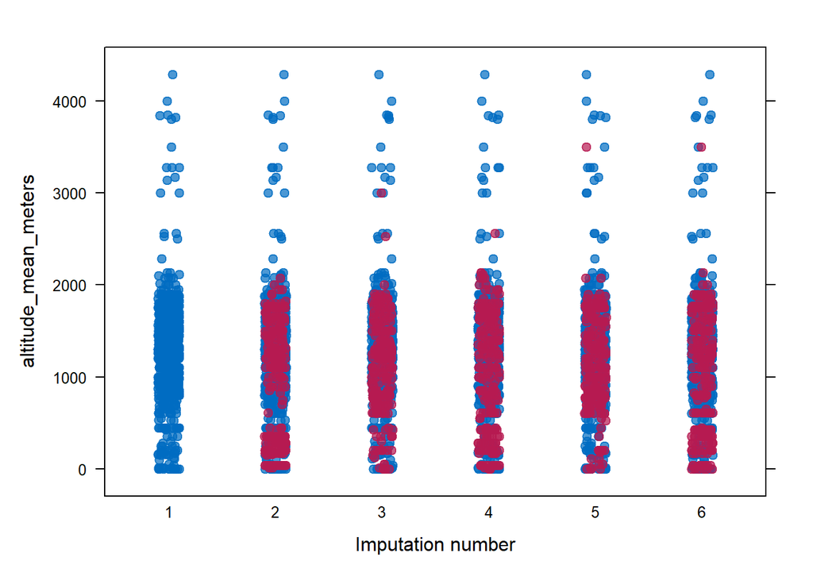

```r
stripplot(imp, altitude_mean_meters ~ .imp, pch = 20, cex = 1.4)
```

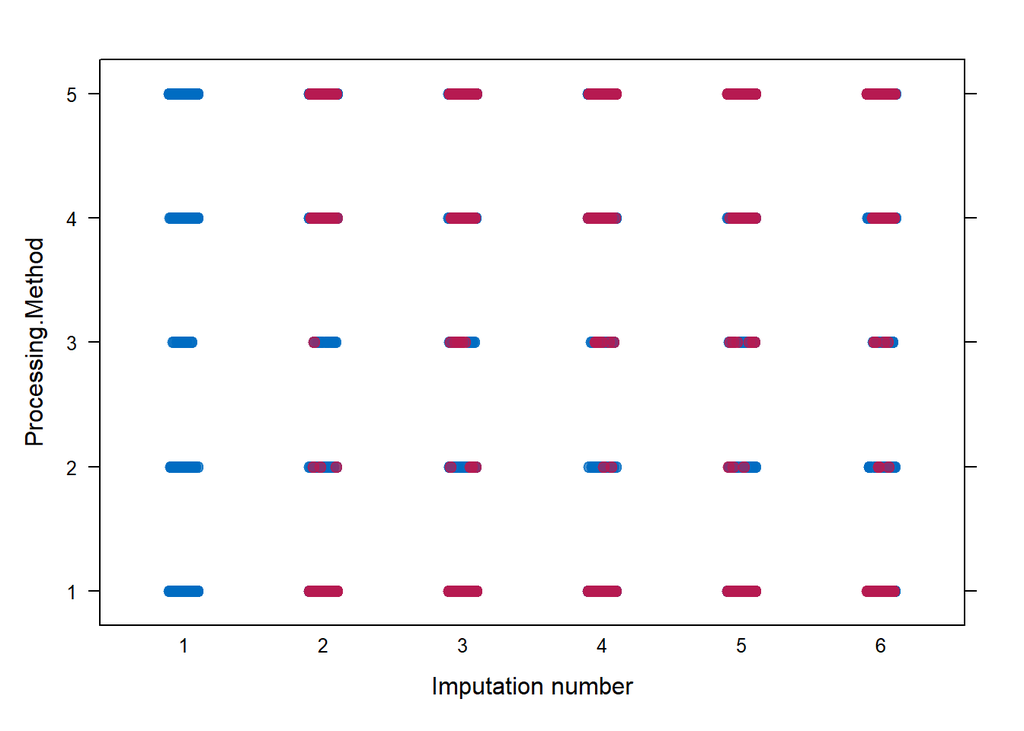

```r
stripplot(imp, Processing.Method ~ .imp, pch = 20, cex = 1.4)
```

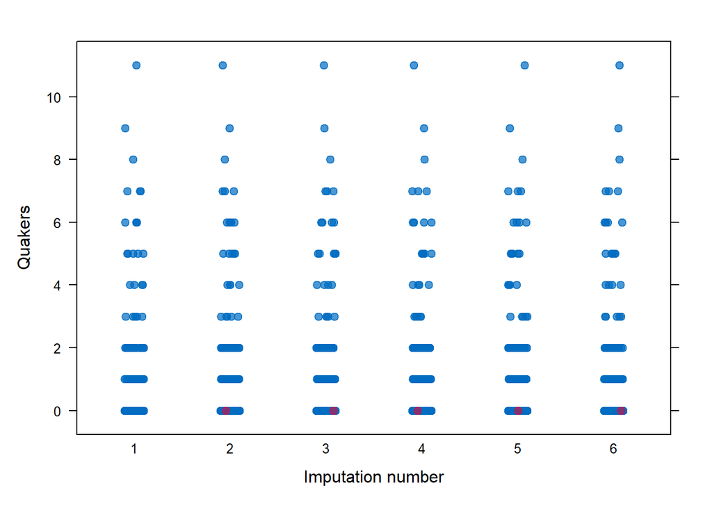

```r
stripplot(imp, Quakers ~ .imp, pch = 20, cex = 1.4)
```

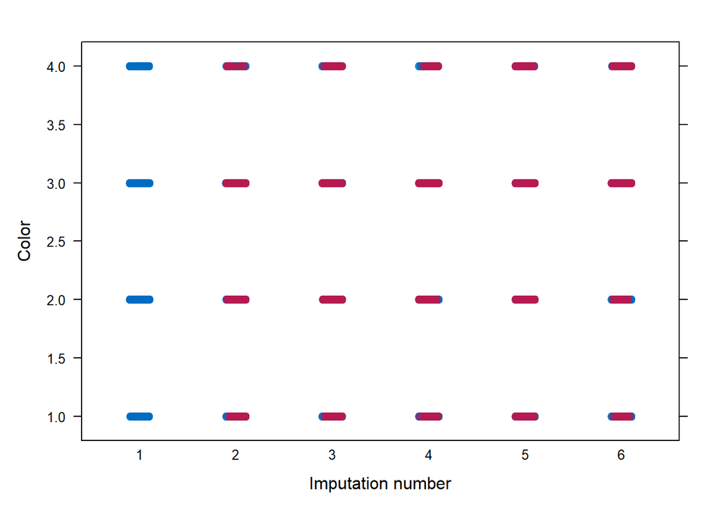

```r
stripplot(imp, Color ~ .imp, pch = 20, cex = 1.4)
```

```r
coffee_imp <- complete(imp)
sum(is.na(coffee_imp))
```

```
## [1] 0
```

Judging from these plots, imputations seem to be adequate.

### Construction of a ‘continent’ variable

We create a continent list for use in filtering in the Shiny visualisation. This list is semi-specific to coffee, using traditional coffee regions like separate Central and South America.

```r
North_America <- c("United States", "United States (Hawaii)", "Mexico", "United States (Puerto Rico)", "Haiti")
Central_America <- c("Guatemala", "Costa Rica", "Honduras",  "Nicaragua","Panama", "El Salvador")
South_America <- c("Brazil", "Peru", "Colombia", "Ecuador")
Africa <- c("Ethiopia", "Uganda", "Tanzania, United Republic Of", "Kenya", "Burundi", "Rwanda", "Malawi", "Zambia", "Mauritius", "Cote d?Ivoire")
Asia <- c("Indonesia", "China", "Taiwan", "Thailand", "Papua New Guinea", "Vietnam", "Philippines", "Laos", "Myanmar", "India", "Japan")


coffee_imp <- coffee_imp %>%
  mutate(Continent = case_when(
    Country.of.Origin %in% Africa ~ "Africa",
    Country.of.Origin %in% Asia ~ "Asia",
    Country.of.Origin %in% Central_America ~ "Central America",
    Country.of.Origin %in% North_America ~ "North America",
    Country.of.Origin %in% South_America ~ "South America",
  )) %>%
  mutate(Continent = as.factor(Continent))

coffee_imp <- coffee_imp %>%
  rowwise() %>%
  mutate(mean_quality = mean(c(Aroma, Flavor, Aftertaste, Acidity, Body, Balance)) %>% round(2)) %>%
  ungroup()

save(coffee_imp, file = "coffee_imp.Rdata")
```